# EC 422 Problem Set 3 Writeup

Author

Jackson Woolfolk

Published

November 1, 2026

**GitHub repo:** https://github.com/Jackson-Woolfolk/ec422_ps3_woolfolk

### 2.2

```r
# a.
# retail_raw <- read.csv("data/retail_sales_raw.csv")
# head(retail_raw)

# b.
retail_raw <- read_csv(
  "data/retail_sales_raw.csv",
  na = ".",
  col_types = cols(
    observation_date = col_date(format = "%Y-%m-%d"),
    RSAFS = col_double(),
    RSAFSNA = col_double()
  )
)
head(retail_raw) |> kable()
```

| observation_date | RSAFS | RSAFSNA |
| --- | --- | --- |
| 1992-01-01 | 159177 | 142051 |
| 1992-02-01 | 159189 | 142498 |
| 1992-03-01 | 158647 | 154439 |
| 1992-04-01 | 159921 | 158430 |
| 1992-05-01 | 160471 | 164788 |
| 1992-06-01 | 161205 | 163417 |

### 2.3

```r
retail_raw_long <- retail_raw |>
  select(observation_date, RSAFS, RSAFSNA) |>
  pivot_longer(cols = c(RSAFS, RSAFSNA), names_to = "series_id", values_to = "sales")
head(retail_raw_long) |> kable()
```

| observation_date | series_id | sales |
| --- | --- | --- |
| 1992-01-01 | RSAFS | 159177 |
| 1992-01-01 | RSAFSNA | 142051 |
| 1992-02-01 | RSAFS | 159189 |
| 1992-02-01 | RSAFSNA | 142498 |
| 1992-03-01 | RSAFS | 158647 |
| 1992-03-01 | RSAFSNA | 154439 |

### 2.4

```r
retail_ts <- retail_raw_long |>
  mutate(Month = yearmonth(observation_date)) |>
  as_tsibble(index = Month, key = series_id)
head(retail_ts) |> kable()
```

| observation_date | series_id | sales | Month |
| --- | --- | --- | --- |
| 1992-01-01 | RSAFS | 159177 | 1992 Jan |
| 1992-02-01 | RSAFS | 159189 | 1992 Feb |
| 1992-03-01 | RSAFS | 158647 | 1992 Mar |
| 1992-04-01 | RSAFS | 159921 | 1992 Apr |
| 1992-05-01 | RSAFS | 160471 | 1992 May |
| 1992-06-01 | RSAFS | 161205 | 1992 Jun |

### 2.5

```r
# a.
head(canadian_gas) |> kable()
```

| Month | Volume |
| --- | --- |
| 1960 Jan | 1.4306 |
| 1960 Feb | 1.3059 |
| 1960 Mar | 1.4022 |
| 1960 Apr | 1.1699 |
| 1960 May | 1.1161 |
| 1960 Jun | 1.0113 |

```r
key_vars(canadian_gas)
```

```
character(0)
```

```r
index_var(canadian_gas)
```

```
[1] "Month"
```

```r
# b.
can_gas <- canadian_gas |>
  select(Month, Volume)

has_gaps(can_gas)
```

```
# A tibble: 1 × 1
  .gaps
  <lgl>
1 FALSE
```

```r
head(can_gas) |> kable()
```

| Month | Volume |
| --- | --- |
| 1960 Jan | 1.4306 |
| 1960 Feb | 1.3059 |
| 1960 Mar | 1.4022 |
| 1960 Apr | 1.1699 |
| 1960 May | 1.1161 |
| 1960 Jun | 1.0113 |

### 2.6

```r
# a.
can_gas_recent <- can_gas |>
  filter(Month >= yearmonth("1990 Jan"))

head(can_gas_recent) |> kable()
```

| Month | Volume |
| --- | --- |
| 1990 Jan | 12.5080 |
| 1990 Feb | 11.1611 |
| 1990 Mar | 11.5871 |
| 1990 Apr | 11.1003 |
| 1990 May | 10.9631 |
| 1990 Jun | 10.1271 |

```r
# b.
can_gas_recent <- can_gas_recent |>
  mutate(year    = year(Month),
         month   = month(Month, label = TRUE),
         quarter = quarter(Month))
head(can_gas_recent) |> kable()
```

| Month | Volume | year | month | quarter |
| --- | --- | --- | --- | --- |
| 1990 Jan | 12.5080 | 1990 | Jan | 1 |
| 1990 Feb | 11.1611 | 1990 | Feb | 1 |
| 1990 Mar | 11.5871 | 1990 | Mar | 1 |
| 1990 Apr | 11.1003 | 1990 | Apr | 2 |
| 1990 May | 10.9631 | 1990 | May | 2 |
| 1990 Jun | 10.1271 | 1990 | Jun | 2 |

```r
can_gas_recent |>
  as_tibble() |>
  group_by(month) |>
  summarize(avg_volume = mean(Volume)) |>
  kable()
```

| month | avg_volume |
| --- | --- |
| Jan | 16.99370 |
| Feb | 15.28472 |
| Mar | 16.33659 |
| Apr | 15.73539 |
| May | 15.74599 |
| Jun | 14.94461 |
| Jul | 15.60248 |
| Aug | 15.61521 |
| Sep | 15.13164 |
| Oct | 16.15769 |
| Nov | 16.18255 |
| Dec | 17.14819 |

```r
# c.
can_gas_recent |>
  mutate(next_month            = Month + 1,
         same_month_last_year = Month - 12) |>
  head() |>
  kable()
```

| Month | Volume | year | month | quarter | next_month | same_month_last_year |
| --- | --- | --- | --- | --- | --- | --- |
| 1990 Jan | 12.5080 | 1990 | Jan | 1 | 1990 Feb | 1989 Jan |
| 1990 Feb | 11.1611 | 1990 | Feb | 1 | 1990 Mar | 1989 Feb |
| 1990 Mar | 11.5871 | 1990 | Mar | 1 | 1990 Apr | 1989 Mar |
| 1990 Apr | 11.1003 | 1990 | Apr | 2 | 1990 May | 1989 Apr |
| 1990 May | 10.9631 | 1990 | May | 2 | 1990 Jun | 1989 May |
| 1990 Jun | 10.1271 | 1990 | Jun | 2 | 1990 Jul | 1989 Jun |

```r
# d.
can_gas_q <- can_gas |>
  filter(Month <= yearmonth("2004 Dec")) |>
  index_by(Quarter = yearquarter(Month)) |>
  summarize(Volume = sum(Volume))

head(can_gas_q) |> kable()
```

| Quarter | Volume |
| --- | --- |
| 1960 Q1 | 4.1387 |
| 1960 Q2 | 3.2973 |
| 1960 Q3 | 2.9744 |
| 1960 Q4 | 4.2577 |
| 1961 Q1 | 5.0055 |
| 1961 Q2 | 4.1670 |

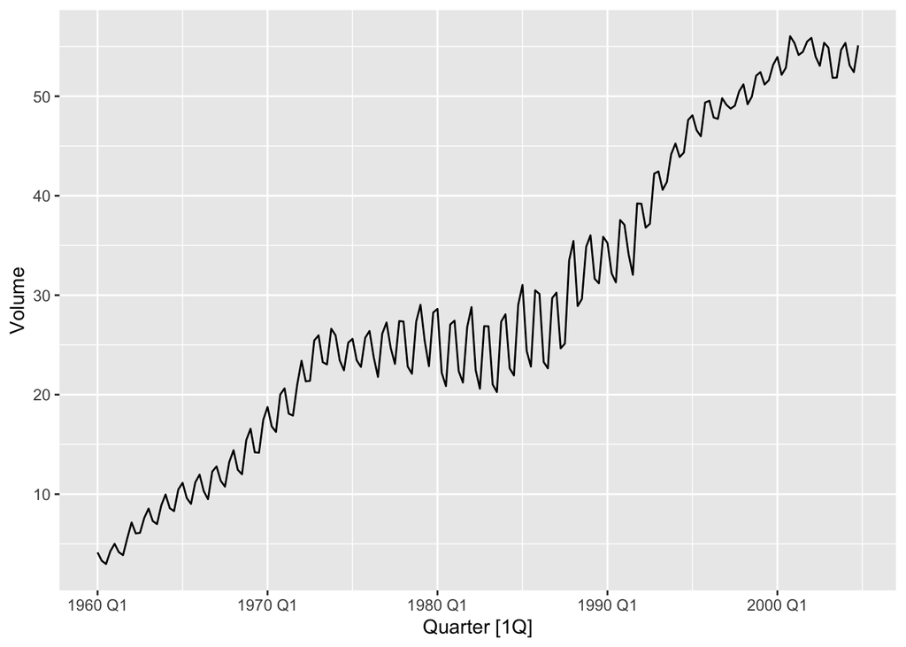

```r
can_gas_q |> autoplot(Volume)
```

### 2.7

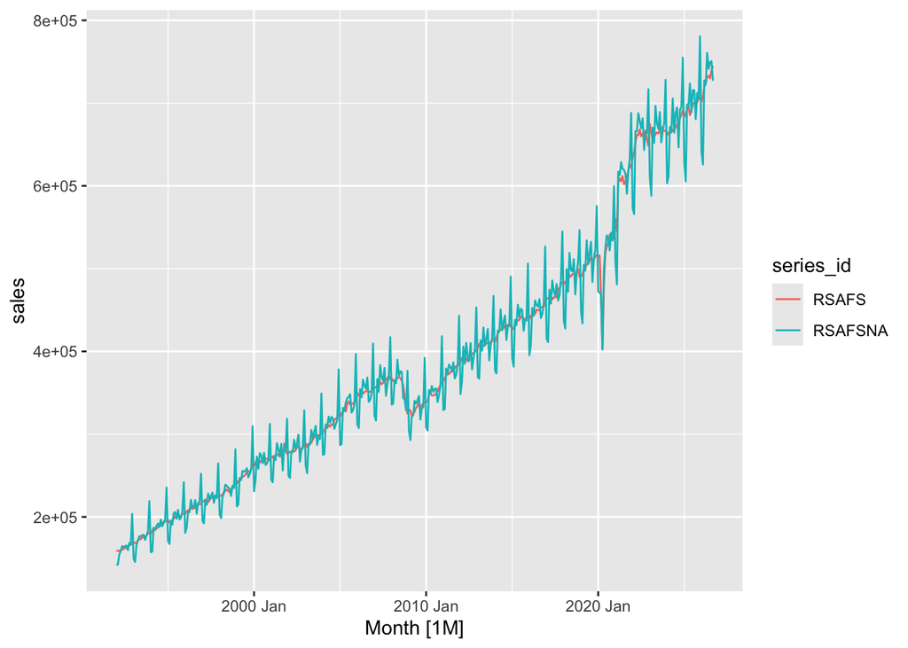

```r
# a.
retail_ts |> autoplot(sales)
```

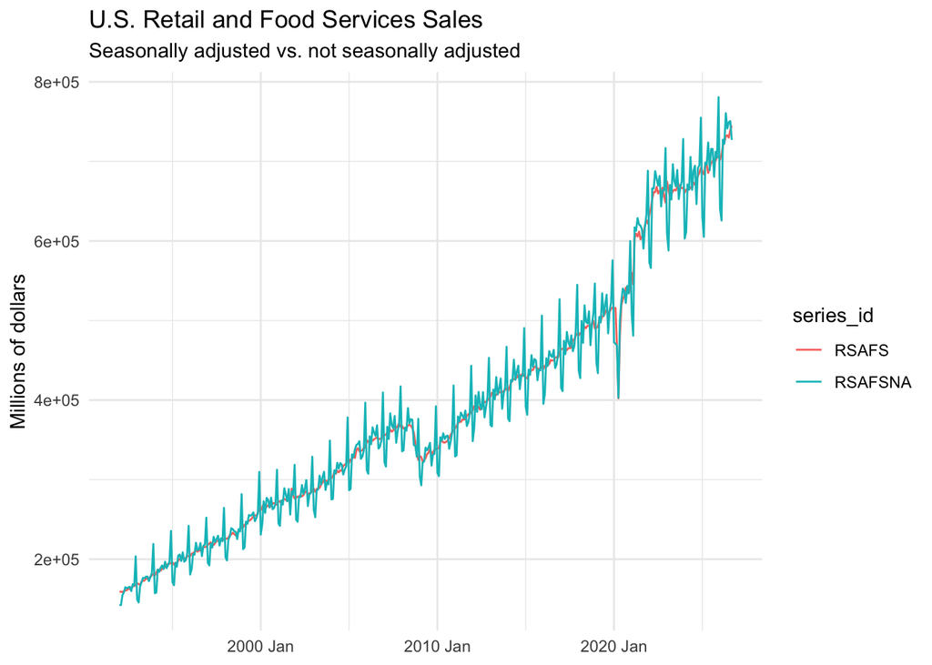

```r
# b.
retail_ts |>
  autoplot(sales) +
  labs(
    title = "U.S. Retail and Food Services Sales",
    subtitle = "Seasonally adjusted vs. not seasonally adjusted",
    x = NULL, y = "Millions of dollars", color = NULL
  ) +
  theme_minimal()
```

The NSA series displays a prominent, sharp spike every December due to holiday shopping, followed by a drop in January. The SA series removes this predictable annual spike, smoothing out the basic seasonal swings so that the underlying economic trend and recessionary drops are clearer.

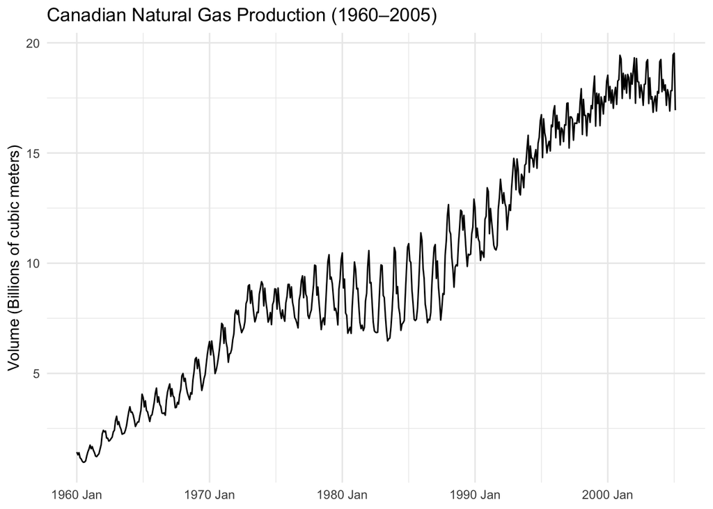

```r
# c.
can_gas |>
  autoplot(Volume) +
  labs(
    title = "Canadian Natural Gas Production (1960–2005)",
    x = NULL,
    y = "Volume (Billions of cubic meters)"
  ) +
  theme_minimal()
```

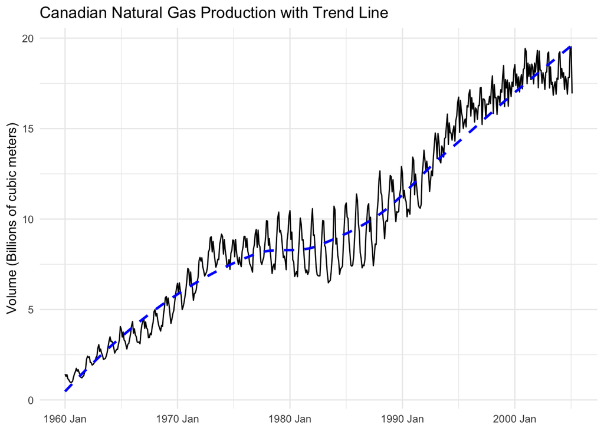

```r
# d.
can_gas |>
  autoplot(Volume) +
  geom_smooth(se = FALSE, color = "blue", linetype = "dashed") +
  labs(
    title = "Canadian Natural Gas Production with Trend Line",
    x = NULL,
    y = "Volume (Billions of cubic meters)"
  ) +
  theme_minimal()
```

## 3. Data Transformation

### 3.1

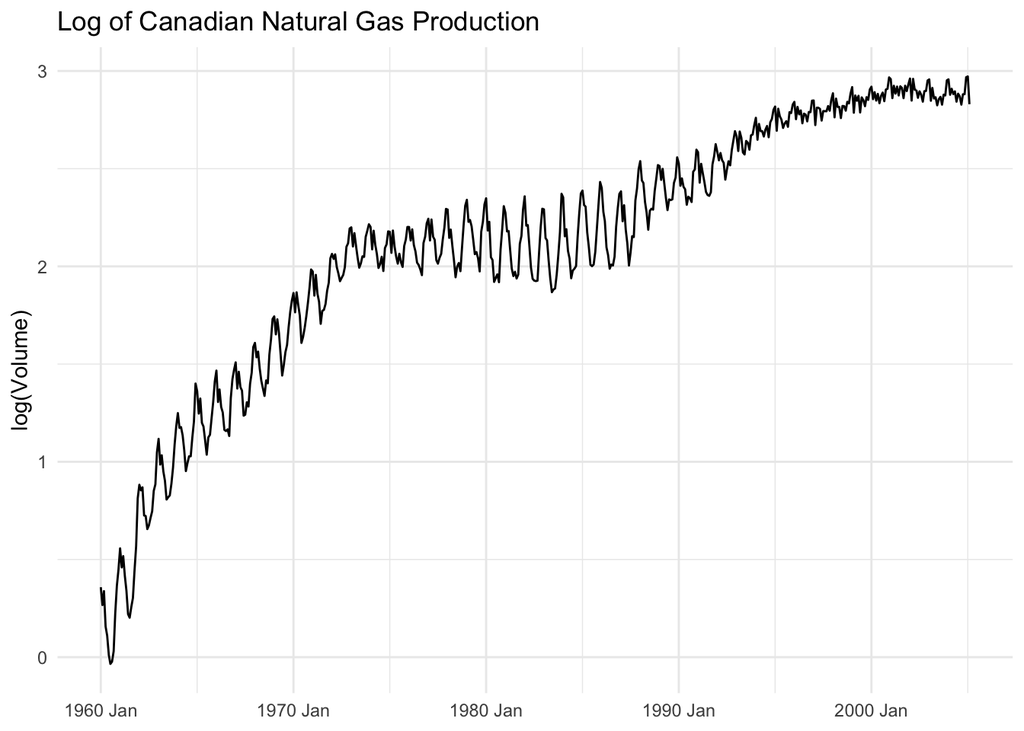

```r
can_gas <- can_gas |>
  mutate(log_volume = log(Volume))

can_gas |>
  autoplot(log_volume) +
  labs(
    title = "Log of Canadian Natural Gas Production",
    x = NULL, y = "log(Volume)"
  ) +
  theme_minimal()
```

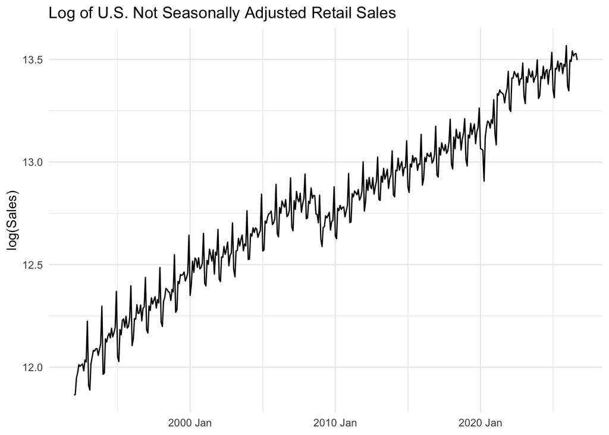

```r
retail_ts |>
  filter(series_id == "RSAFSNA") |>
  mutate(log_sales = log(sales)) |>
  autoplot(log_sales) +
  labs(
    title = "Log of U.S. Not Seasonally Adjusted Retail Sales",
    x = NULL, y = "log(Sales)"
  ) +
  theme_minimal()
```

### 3.2

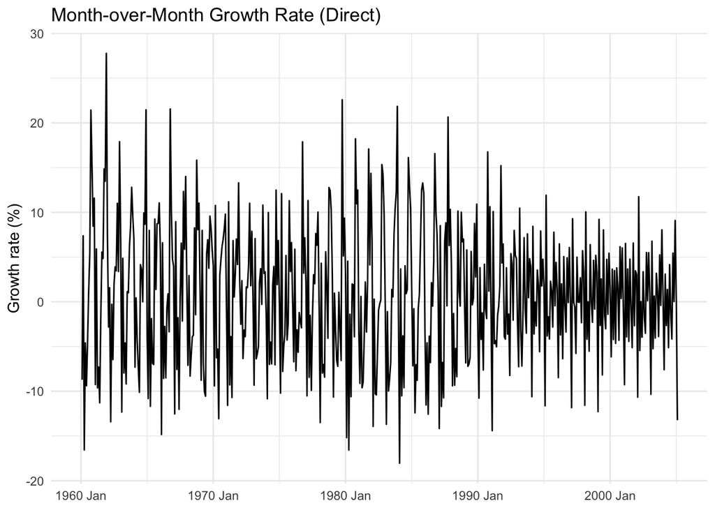

```r
can_gas <- can_gas |>
  mutate(
    growth_direct  = 100 * difference(Volume) / lag(Volume),
    growth_logdiff = 100 * difference(log_volume)
  )

can_gas |>
  autoplot(growth_direct) +
  labs(
    title = "Month-over-Month Growth Rate (Direct)",
    x = NULL, y = "Growth rate (%)"
  ) +
  theme_minimal()
```

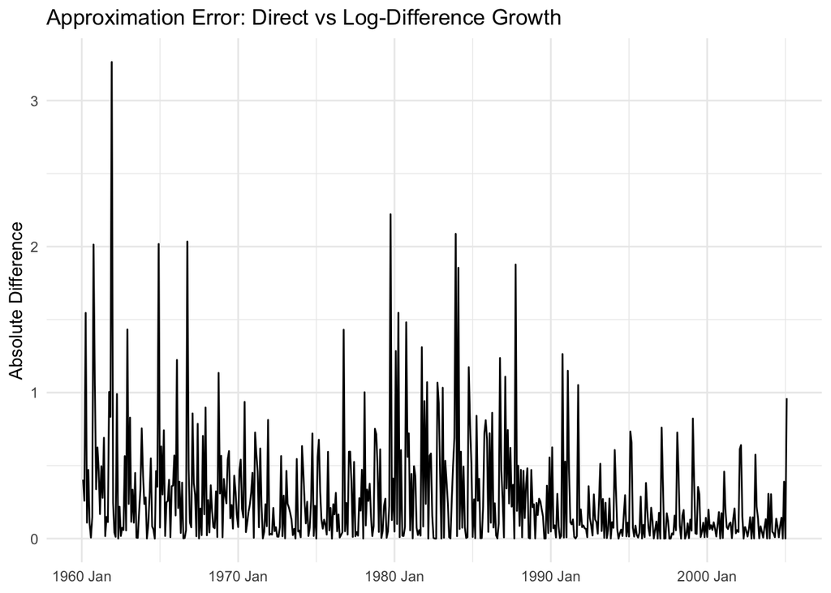

```r
can_gas <- can_gas |>
  mutate(growth_gap = abs(growth_direct - growth_logdiff))

can_gas |>
  autoplot(growth_gap) +
  labs(
    title = "Approximation Error: Direct vs Log-Difference Growth",
    x = NULL, y = "Absolute Difference"
  ) +
  theme_minimal()
```

The absolute difference plot shows that the log-difference approximation is extremely close to the exact percentage growth rate when monthly changes are small.

### 3.3

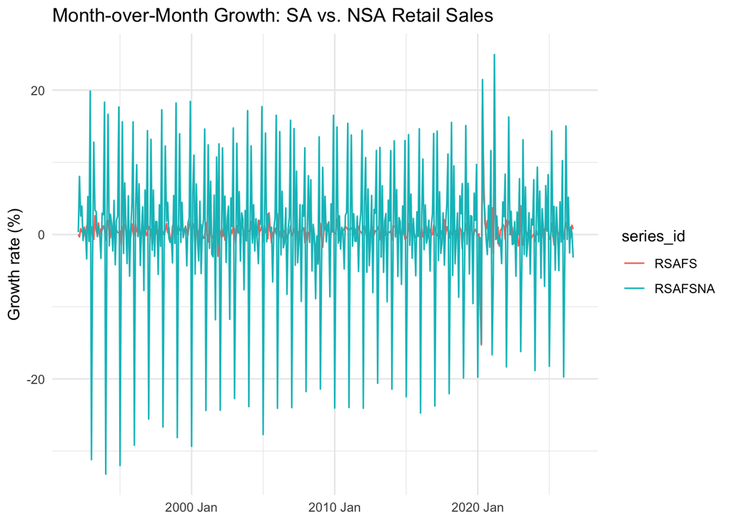

```r
retail_ts <- retail_ts |>
  group_by_key() |>
  mutate(growth_mom = 100 * difference(log(sales))) |>
  ungroup()

retail_ts |>
  autoplot(growth_mom) +
  labs(
    title = "Month-over-Month Growth: SA vs. NSA Retail Sales",
    x = NULL, y = "Growth rate (%)", color = NULL
  ) +
  theme_minimal()
```

The NSA growth rate series is significantly noisier than the SA series because it still contains monthly jumps that repeat each year and create massive spikes. The SA series filters those out, leaving a cleaner picture of monthly economic momentum.

## 4. Seeing, Decomposing, and Modeling Seasonality

### 4.1

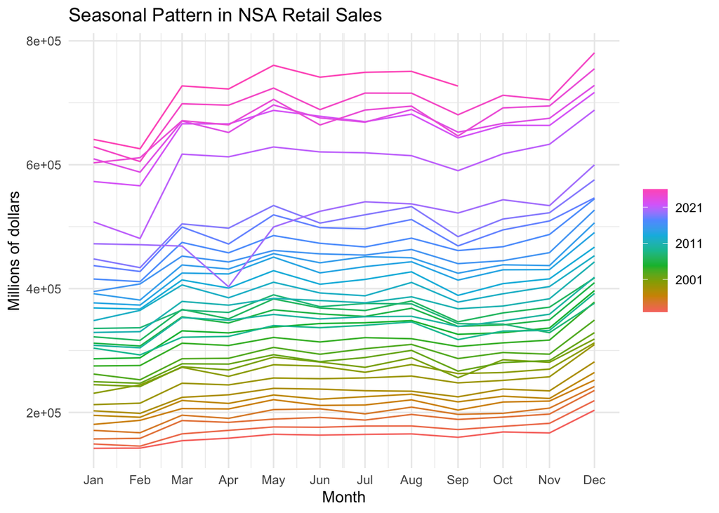

```r
retail_ts |>
  filter(series_id == "RSAFSNA") |>
  gg_season(sales) +
  labs(
    title = "Seasonal Pattern in NSA Retail Sales",
    y = "Millions of dollars"
  ) +
  theme_minimal()
```

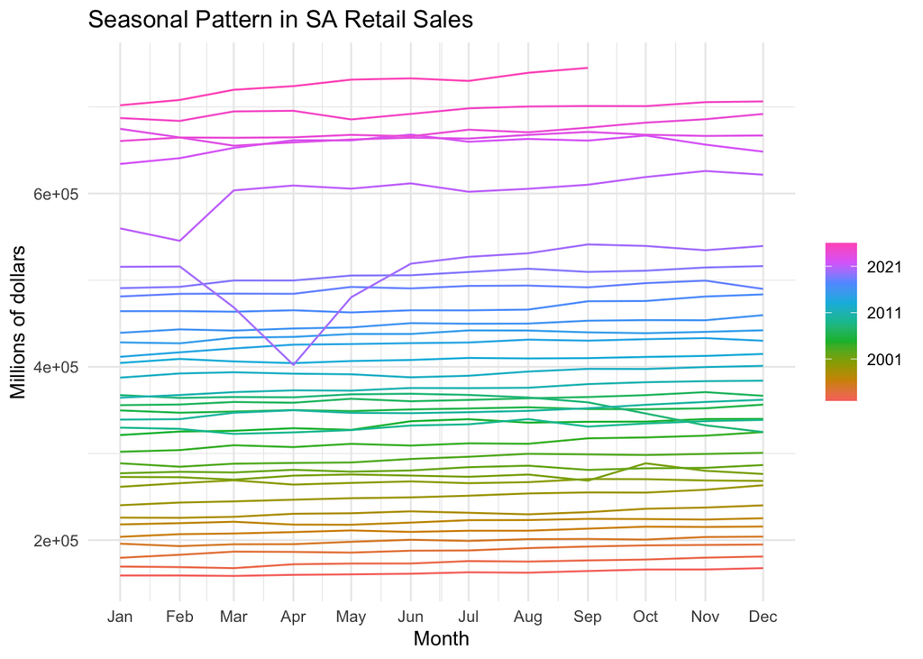

```r
retail_ts |>
  filter(series_id == "RSAFS") |>
  gg_season(sales) +
  labs(
    title = "Seasonal Pattern in SA Retail Sales",
    y = "Millions of dollars"
  ) +
  theme_minimal()
```

The SA plot is much flatter than the NSA plot, indicating that the seasonal adjustment process has successfully removed the predictable annual spikes and drops, leaving a more stable series.

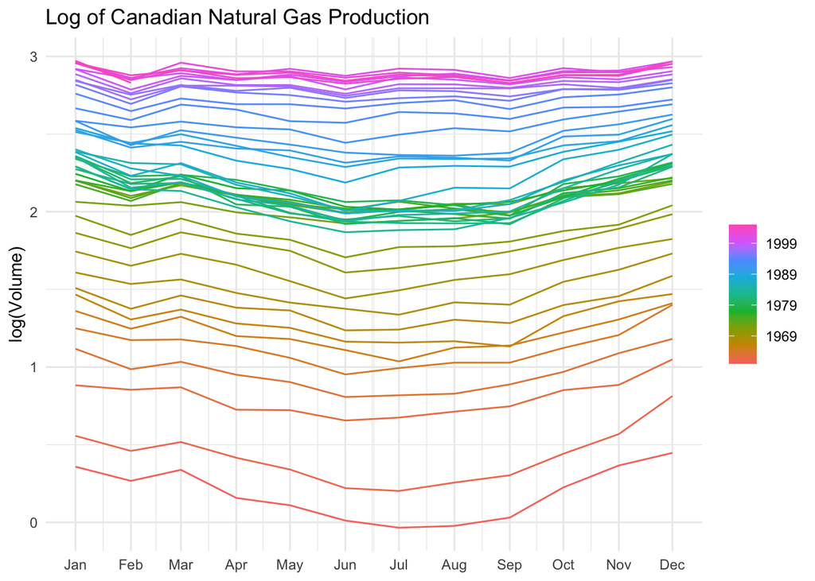

```r
can_gas |>
  gg_season(log_volume) +
  labs(
    title = "Log of Canadian Natural Gas Production",
    y = "log(Volume)", x = NULL
  ) +
  theme_minimal()
```

### 4.2

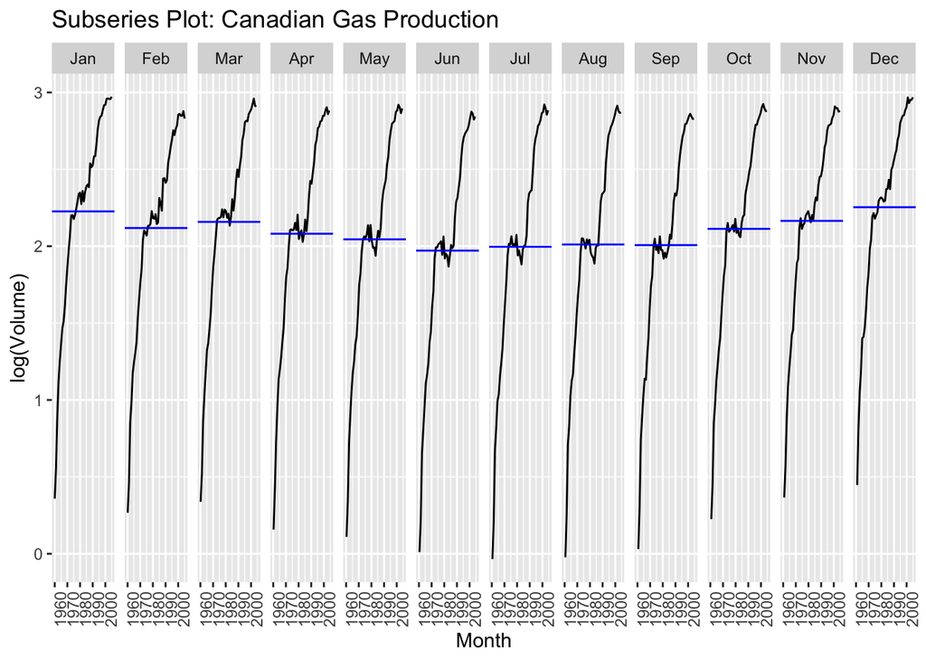

```r
can_gas |>
  gg_subseries(log_volume) +
  labs(
    title = "Subseries Plot: Canadian Gas Production",
    y = "log(Volume)"
  )
```

### 4.3

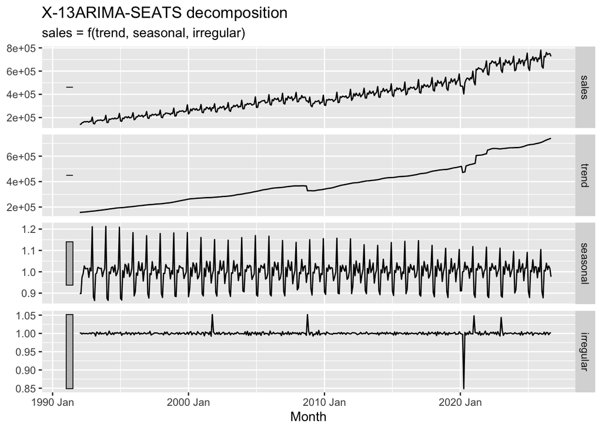

```r
# install.packages("seasonal")

retail_nsa_x13 <- retail_ts |>
  filter(series_id == "RSAFSNA") |>
  model(x13 = X_13ARIMA_SEATS(sales)) |>
  components()

retail_nsa_x13 |> autoplot()
```

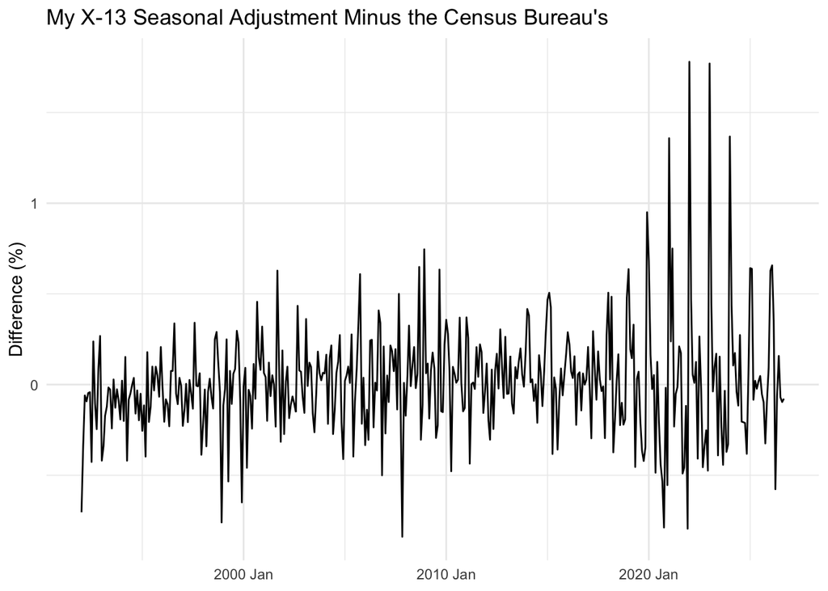

```r
sa_compare <- retail_nsa_x13 |>
  as_tibble() |>
  select(Month, mine = season_adjust) |>
  left_join(
    retail_ts |>
      filter(series_id == "RSAFS") |>
      as_tibble() |>
      transmute(Month, census = sales),
    by = "Month"
  ) |>
  mutate(pct_diff = 100 * (log(mine) - log(census)))

sa_compare |>
  ggplot(aes(x = Month, y = pct_diff)) +
  geom_line() +
  labs(
    title = "My X-13 Seasonal Adjustment Minus the Census Bureau's",
    x = NULL, y = "Difference (%)"
  ) +
  theme_minimal()
```

### 4.4

```r
can_gas_fit <- can_gas |>
  model(TSLM(log_volume ~ trend() + season()))

report(can_gas_fit)
```

```
Series: log_volume
Model: TSLM

Residuals:
      Min        1Q    Median        3Q       Max
-0.985307 -0.096451 -0.004525  0.131639  0.470564

Coefficients:
                 Estimate Std. Error t value Pr(>|t|)
(Intercept)     1.150e+00  4.142e-02  27.761  < 2e-16 ***
trend()         3.973e-03  6.886e-05  57.692  < 2e-16 ***
season()year2  -1.121e-01  5.229e-02  -2.144  0.03245 *
season()year3  -5.238e-02  5.258e-02  -0.996  0.31963
season()year4  -1.334e-01  5.258e-02  -2.537  0.01146 *
season()year5  -1.738e-01  5.258e-02  -3.305  0.00101 **
season()year6  -2.512e-01  5.258e-02  -4.777 2.30e-06 ***
season()year7  -2.300e-01  5.258e-02  -4.374 1.47e-05 ***
season()year8  -2.193e-01  5.258e-02  -4.170 3.56e-05 ***
season()year9  -2.274e-01  5.258e-02  -4.325 1.83e-05 ***
season()year10 -1.253e-01  5.258e-02  -2.383  0.01753 *
season()year11 -7.781e-02  5.258e-02  -1.480  0.13956
season()year12  7.202e-03  5.258e-02   0.137  0.89111
---
Signif. codes:  0 '***' 0.001 '**' 0.01 '*' 0.05 '.' 0.1 ' ' 1

Residual standard error: 0.2508 on 529 degrees of freedom
Multiple R-squared: 0.8652, Adjusted R-squared: 0.8622
F-statistic:   283 on 12 and 529 DF, p-value: < 2.22e-16
```

```r
can_gas_fit |>
  tidy() |>
  select(term, estimate, std.error, statistic, p.value) |>
  knitr::kable(digits = 3)
```

| term | estimate | std.error | statistic | p.value |
| --- | --- | --- | --- | --- |
| (Intercept) | 1.150 | 0.041 | 27.761 | 0.000 |
| trend() | 0.004 | 0.000 | 57.692 | 0.000 |
| season()year2 | -0.112 | 0.052 | -2.144 | 0.032 |
| season()year3 | -0.052 | 0.053 | -0.996 | 0.320 |
| season()year4 | -0.133 | 0.053 | -2.537 | 0.011 |
| season()year5 | -0.174 | 0.053 | -3.305 | 0.001 |
| season()year6 | -0.251 | 0.053 | -4.777 | 0.000 |
| season()year7 | -0.230 | 0.053 | -4.374 | 0.000 |
| season()year8 | -0.219 | 0.053 | -4.170 | 0.000 |
| season()year9 | -0.227 | 0.053 | -4.325 | 0.000 |
| season()year10 | -0.125 | 0.053 | -2.383 | 0.018 |
| season()year11 | -0.078 | 0.053 | -1.480 | 0.140 |
| season()year12 | 0.007 | 0.053 | 0.137 | 0.891 |

Estimated average monthly growth rate for Canadian gas production comes from the trend coefficient, approximately 0.4%. The biggest seasonal effect occurs in June, with the largest absolute value t-statistic, -4.777.

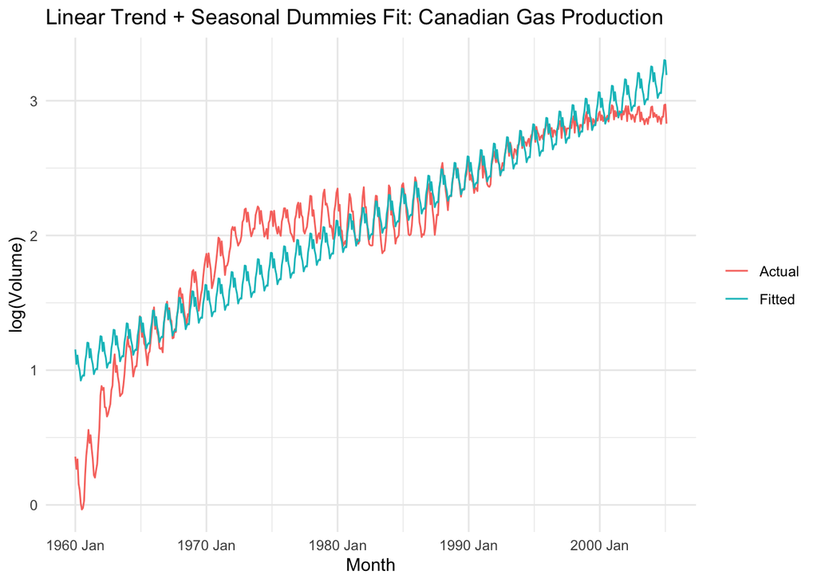

```r
can_gas_fit |>
  augment() |>
  ggplot(aes(x = Month)) +
  geom_line(aes(y = log_volume, color = "Actual")) +
  geom_line(aes(y = .fitted, color = "Fitted")) +
  labs(title = "Linear Trend + Seasonal Dummies Fit: Canadian Gas Production",
       y = "log(Volume)", color = NULL) +
  theme_minimal()
```

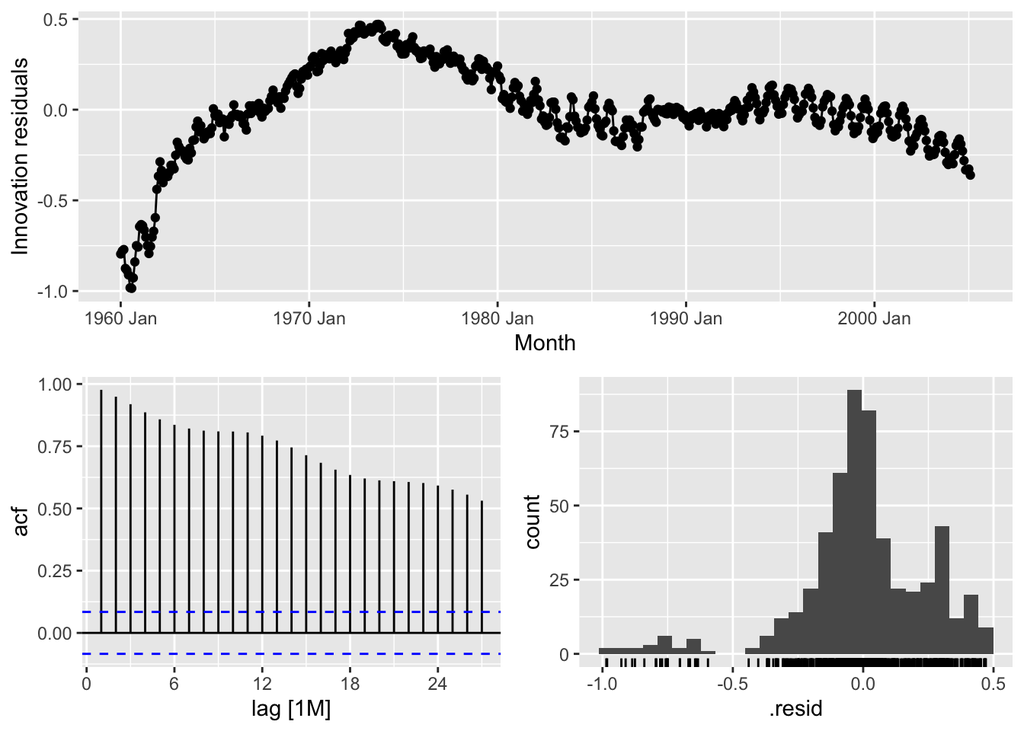

```r
can_gas_fit |> gg_tsresiduals()
```

```r
can_gas_fit |>
  augment() |>
  features(.innov, ljung_box, lag = 24) |>
  kable()
```

| .model | lb_stat | lb_pvalue |
| --- | --- | --- |
| TSLM(log_volume ~ trend() + season()) | 7774.218 | 0 |

Based on the tibble output, the residuals do not look like white noise; there is a visible structure and autocorrelation left in them that could be modeled further. The Ljung–Box test yields a p-value of 0, leading us to strongly reject the null hypothesis of white noise at the 5% significance level and conclude that significant predictable patterns remain in the model.

### 5. A First Forecast Evaluation

## 5.1

```r
gas_cv_fc <- can_gas |>
  select(Month, Volume) |>
  stretch_tsibble(.init = 240, .step = 1) |>
  model(snaive = SNAIVE(Volume),
        tslm   = TSLM(log(Volume) ~ trend() + season())) |>
  forecast(h = 1)

gas_cv_fc |>
  accuracy(can_gas, measures = list(MAE = MAE, RMSE = RMSE)) |>
  kable()
```

| .model | .type | MAE | RMSE |
| --- | --- | --- | --- |
| snaive | Test | 0.5619689 | 0.7015278 |
| tslm | Test | 4.0085720 | 4.3624326 |

The Seasonal Naive model forecasts significantly more accurately than the TSLM model, yielding much lower error values. Both the MAE and RMSE metrics support this conclusion.

### 5.2

```r
errs <- gas_cv_fc |>
  as_tibble() |>
  left_join(as_tibble(can_gas) |> select(Month, actual = Volume),
            by = "Month") |>
  mutate(e = actual - .mean) |>
  select(Month, .model, e) |>
  pivot_wider(names_from = .model, values_from = e) |>
  na.omit()

forecast::dm.test(errs$snaive, errs$tslm, h = 1, power = 1)
```

```
    Diebold-Mariano Test

data:  errs$snaiveerrs$tslm
DM = -31.278, Forecast horizon = 1, Loss function power = 1, p-value <
2.2e-16
alternative hypothesis: two.sided
```

The Diebold-Mariano test shows a highly significant difference in forecast accuracy between the two models, with the negative DM statistic confirming that the seasonal naive model yields significantly smaller forecast errors than the tslm model.

### 5.3

```r
gas_rolling_fc <- can_gas |>
  select(Month, Volume) |>
  slide_tsibble(.size = 240, .step = 1) |>
  model(
    snaive = SNAIVE(Volume),
    tslm   = TSLM(log(Volume) ~ trend() + season())
  ) |>
  forecast(h = 1)

gas_rolling_fc |>
  accuracy(can_gas, measures = list(MAE = MAE, RMSE = RMSE)) |>
  kable()
```

| .model | .type | MAE | RMSE |
| --- | --- | --- | --- |
| snaive | Test | 0.5619689 | 0.7015278 |
| tslm | Test | 2.0945436 | 2.4245541 |